# Capstone-W2-ExploreData

## Load files

The english text datasets were acquired from Twitter, News and Blogs. I’ve loaded the files and performed the basic analysis below.

```
## Reading dataset  dstwitter  from  C:\temp\en_US.twitter.txt
## --- Twitter  dataset stats---
## Lines loaded:  2360148
## Maximum line length 213
## Average line length 68.80281
## Median line length 64
## Number of words 32874008
## 301.4 Mb
##
##
## Reading dataset  dsnews  from  C:\temp\en_US.news.txt
## --- News  dataset stats---
## Lines loaded:  77258
## Maximum line length 5760
## Average line length 203.0041
## Median line length 186
## Number of words 2837474
## 19.2 Mb
##
##
## Reading dataset  dsblogs  from  C:\temp\en_US.blogs.txt
## --- Blogs  dataset stats---
## Lines loaded:  899288
## Maximum line length 40835
## Average line length 231.696
## Median line length 157
## Number of words 39386844
## 248.5 Mb
```

## Summaries

This has been collected into a metric table

```
##              name   lines   max      mean median    words
## dstwitter Twitter 2360148   213  68.80281     64 32874008
## dsnews       News   77258  5760 203.00412    186  2837474
## dsblogs     Blogs  899288 40835 231.69601    157 39386844
```

## Graphs

[figure not shown]

## Interesting findings

- 1. Although twitter has the most lines, Blogs has more words.
- 2. Maybe twitter is more of a spoken language useful in predicting text message words because it consists of shorter sentenses
- 3. The following are the most common phrases in my first 10000 lines. I removed punctuation and stop words, but maybe I should not because it garables the results compared to real input.

Here’s my tm() exploration of the few chunks of twitter dataset. For my dynamic “somegrams” I used maximum and minimum 2-grams

```
## [1] "Reloading corpus"
## [1] "Performing step  1  of  2  start line =  1"
## [1] "Loaded chunk file size"
## 659.7 Kb
## [1] "Performing step  2  of  2  start line =  5001"
## [1] "Loaded chunk file size"
## 658.4 Kb
```

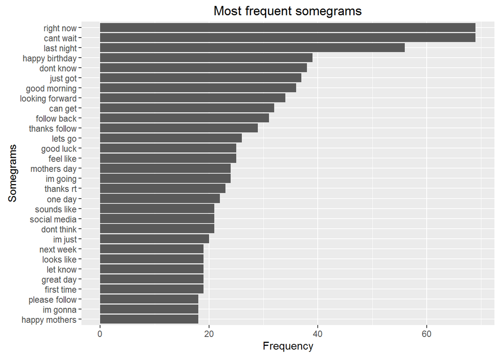

## Plans for application

- 1. I will create lists of 2,3,4 n-grams across all datasets. They will serve as markov chain predictors (if i got that right)
- 2. I will build shiny application with one input box where user types in text
- 3. On user input I grab 4-3-2 last words and display most likely next word occurences.